# Practice time!

# Hierarchical clustering

## Data

In this session, we are going to continue using the `protein.csv` data set from previous session. We start by loading and preparing the data set.

```r
data.protein = read.csv("source/protein.csv")
rownames(data.protein) = data.protein$Country
data.protein$Country = NULL
data.protein = as.data.frame(scale(data.protein))
```

## Creating an agglomerative cluster

To create a hierarchical agglomerative cluster, we will use the function `hclust` from R base. The basic syntax of this function is `hclust(d, method)`, where `d` is a matrix of pairwise distaces between the observations and `method` describes the criterion used to join different clusters.

To compute `d`, we can use the function `dist`.

```r
d = dist(data.protein)
```

|  | Albania | Austria | Belgium | Bulgaria | Czechoslovakia | Denmark |
| --- | --- | --- | --- | --- | --- | --- |
| Albania | 0.000000 | 6.136051 | 5.948761 | 2.764537 | 5.141148 | 6.634163 |
| Austria | 6.136051 | 0.000000 | 2.451322 | 4.900277 | 2.130891 | 3.019238 |
| Belgium | 5.948761 | 2.451322 | 0.000000 | 5.237088 | 2.220255 | 2.539115 |
| Bulgaria | 2.764537 | 4.900277 | 5.237088 | 0.000000 | 3.950363 | 6.036592 |
| Czechoslovakia | 5.141148 | 2.130891 | 2.220255 | 3.950363 | 0.000000 | 3.369219 |
| Denmark | 6.634163 | 3.019238 | 2.539115 | 6.036592 | 3.369219 | 0.000000 |

Function `dist` by default computes the euclidean distance, but we can specify other distances as well, with the parameter `method`.

```r
set.seed(2018)
hc = hclust(d, method = "complete")
hc
```

```
##
## Call:
## hclust(d = d, method = "complete")
##
## Cluster method   : complete
## Distance         : euclidean
## Number of objects: 25
```

We can plot the resultant dendrogram with the package `factoextra`.

```r
library(factoextra)
```

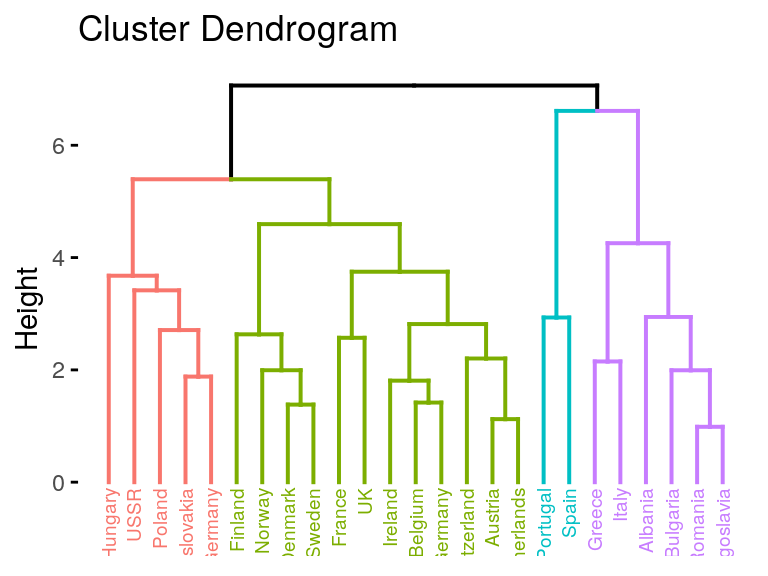

```r
fviz_dend(hc, k = 4, cex=0.5)
```

### Linkages: Parameter `method` in `hclust`

Varying the parameter `method` in `hclust` function call, produces different dendrogams.

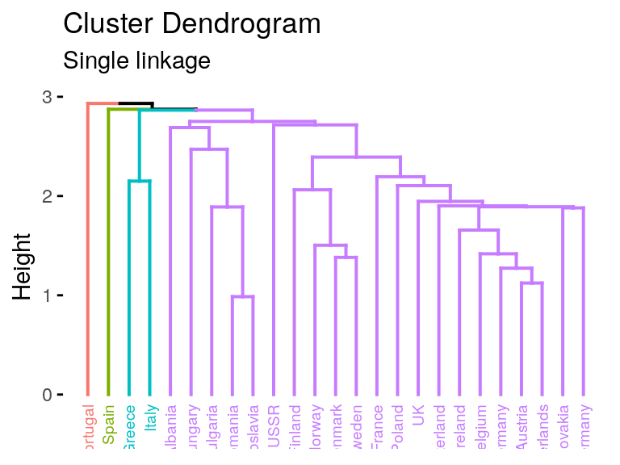

```r
hc = hclust(d, method = "single")
fviz_dend(hc, k = 4, cex=0.5)+labs(subtitle = "Single linkage")
```

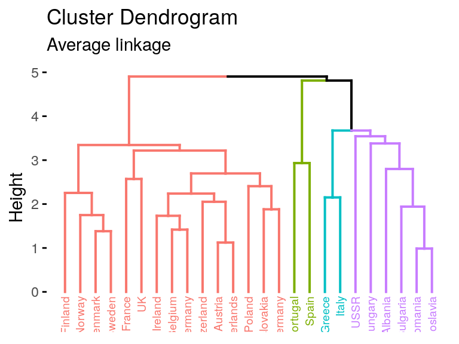

```r
hc = hclust(d, method = "average")
fviz_dend(hc, k = 4, cex=0.5)+labs(subtitle = "Average linkage")
```

### Method `cutree`

Function `cutree` makes a horizontal cut in the dendrogram. We can provide either one of `k` (number of groups) or `h` (height at which to cut the tree)

```r
cutree(hc, k = 4)
```

```
##        Albania        Austria        Belgium       Bulgaria Czechoslovakia
##              1              2              2              1              2
##        Denmark      E Germany        Finland         France         Greece
##              2              2              2              2              3
##        Hungary        Ireland          Italy    Netherlands         Norway
##              1              2              3              2              2
##         Poland       Portugal        Romania          Spain         Sweden
##              2              4              1              4              2
##    Switzerland             UK           USSR      W Germany     Yugoslavia
##              2              2              1              2              1
```

Notice that `cutree` returns a named vector with the same structure as field `cluster` returned by the function `kmeans`.

# Color quantization with kmeans

In this part, we will illustrate the use of kmeans in image segmentation (color quantization). We will use the `OpenImageR` library for R.

We start by downloading and reading the picture into R.

```r
library(OpenImageR)

#url = 'http://kiwi.uc3m.es/datos-curso-deloitte/Cave1.png'
#download.file(url, destfile = 'Cave1.png')

img = readImage('source/Cave1.png')
dim(img)
```

```
## [1] 381 514   3
```

This picture has a resolution of `514 x 381` px, separated in three color chanels (R, G, B), thus we actually have `381*514=195834` observations and `3` variables. We can use the function `imageShow` to plot the picture.

[figure not shown]

```r
imageShow(img)
```

Since this is an example, we are going to resize this picture to a lower resolution, so `kmeans` runs faster.

```r
img1 = resizeImage(img, width = 190, height = 257, method = "bilinear")
dim(img1)
```

```
## [1] 190 257   3
```

[figure not shown]

```r
imageShow(img1)
```

```r
img1.vect = apply(img1, 3, as.vector)
dim(img1.vect)
```

```
## [1] 48830     3
```

We are now ready to cluster our data using `kmeans`.

```r
set.seed(2018)
km = kmeans(img1.vect, centers = 4)
```

Next, we substitute each pixel by the center of its cluster, and take the new segmented image to the original format.

[figure not shown]

```r
img2 = km$centers[km$cluster,]
dim(img2) = dim(img1)

imageShow(img2)
```